# Project1 Reproducible Research

**Load the data:**

```r
        working.dir <- "/Users/camilla/Projects/ReproducibleResearch/RawData/activity.csv"
        data <- read.csv(file = working.dir)
```

**What is the mean total number of steps taken per day?**

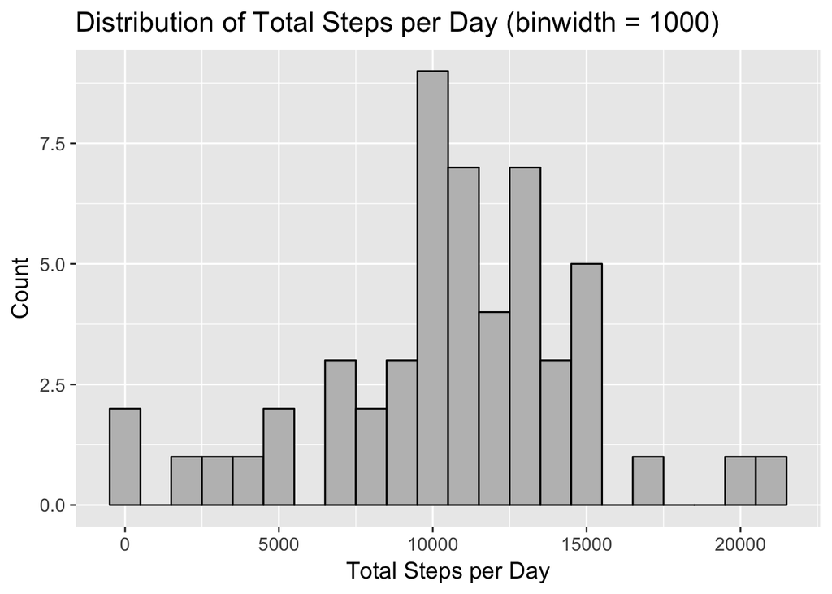

The mean total number of steps per day is 1.076610^{4} and the median total steps per day is 10765.

**What is the average daily activity pattern?**

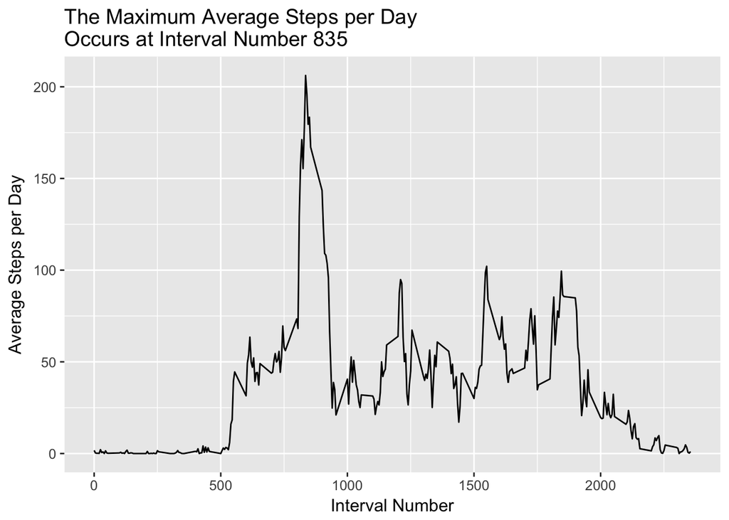

Interval 835 contains the maximum number of steps.

**Inputing missing values**

```r
        #replace missing values
        #create new dataset with only missing values
        data.incomplete <- data[!complete.cases(data),]
        #nrow(data.incomplete) #should be 2304
        #merge missing values dataset with average steps per interval by interval num
        data.fill <- merge(data.incomplete,avgspi, by="interval")[-2]
        #rearrange and rename columns to match complete dataset
        data.fill <- data.fill[,c(3,2,1)]
        colnames(data.fill) <- c("steps","date","interval")
        #append filled in data to complete data
        all.data <- rbind(complete.data,data.fill)
```

**What is the mean total number of steps taken per day with added values?**

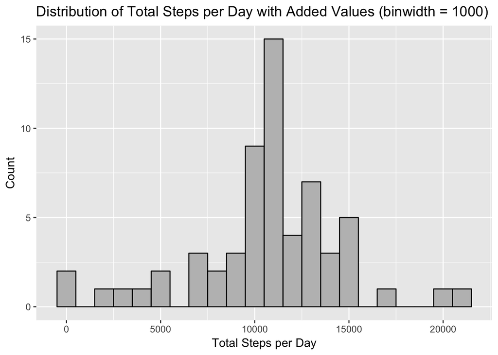

The mean total number of steps per day is 1.076610^{4} and the median total steps per day is 1.076610^{4}.

The mean and median values of average steps per day are not largely affected by missing data. The mean steps per day did not change at 1.076610^{4} steps. The median steps per day changed from 10765 steps to 1.076610^{4} steps.

**Are there differences in activity patterns between weekdays and weekends?**

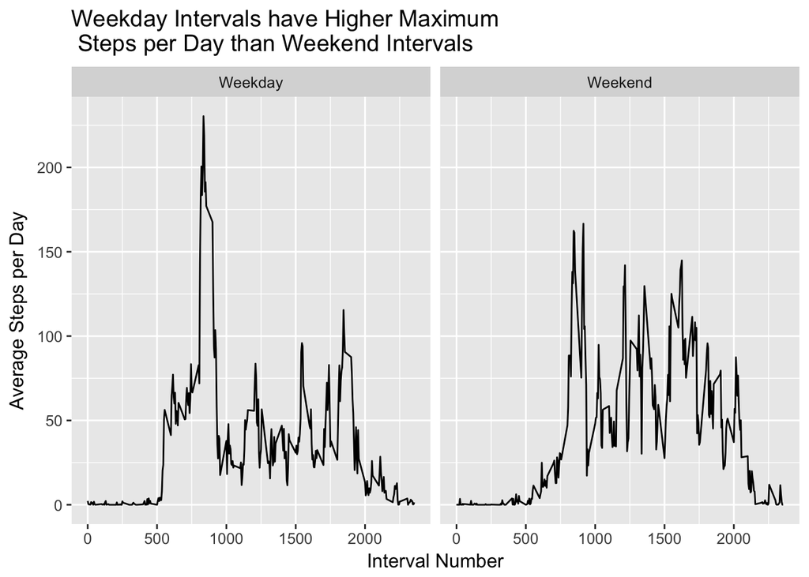